# 🦇 Convolutional Neural Networks: The Main Components (Color)

## Practice 2: Solution (b) — All Four Windows

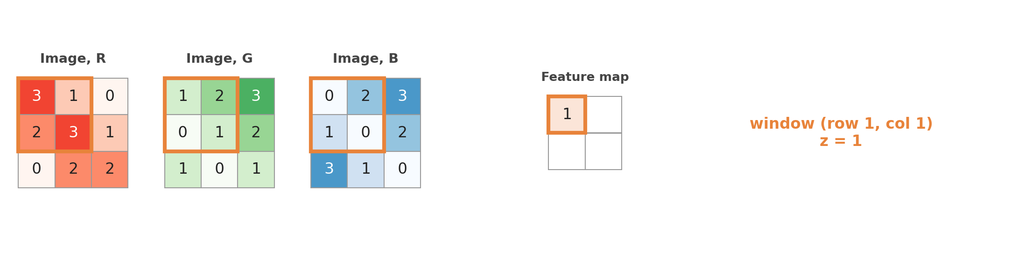

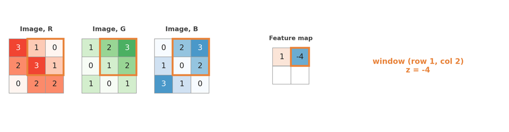

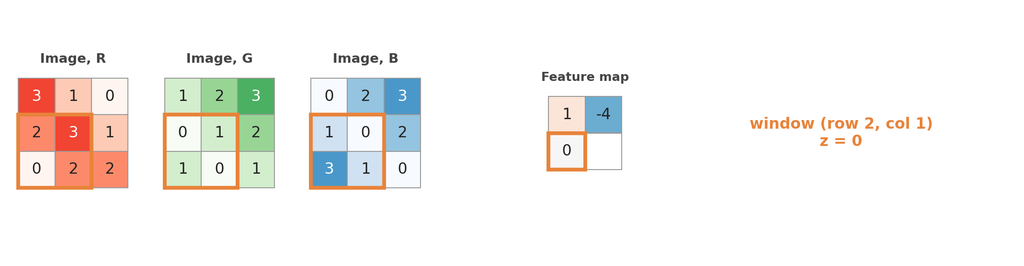

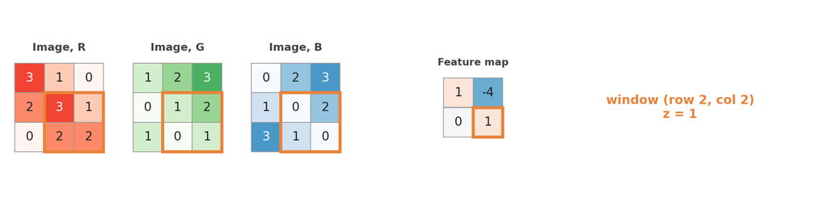

| Window (row, col) | R part (top row of red) | G part (bottom row of green) | B part (−all blue) | $z$ = sum − 1 |
| --- | --- | --- | --- | --- |
| (1, 1) | $3 + 1 = 4$ | $0 + 1 = 1$ | $-(0 + 2 + 1 + 0) = -3$ | $4 + 1 - 3 - 1 = 1$ |
| (1, 2) | $1 + 0 = 1$ | $1 + 2 = 3$ | $-(2 + 3 + 0 + 2) = -7$ | $1 + 3 - 7 - 1 = -4$ |
| (2, 1) | $2 + 3 = 5$ | $1 + 0 = 1$ | $-(1 + 0 + 3 + 1) = -5$ | $5 + 1 - 5 - 1 = 0$ |
| (2, 2) | $3 + 1 = 4$ | $0 + 1 = 1$ | $-(0 + 2 + 1 + 0) = -3$ | $4 + 1 - 3 - 1 = 1$ |

## Practice 2: Solution (c, d) — ReLU and Parameters

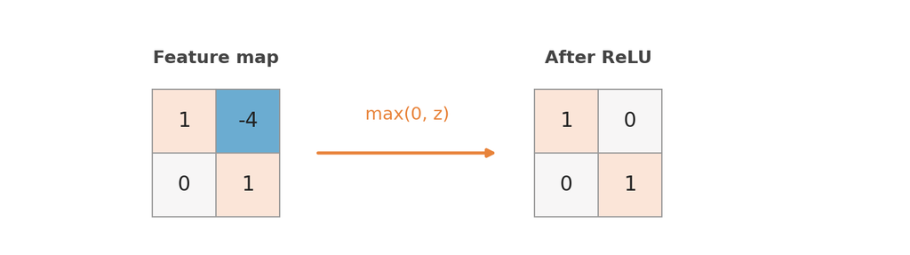

- **c.** ReLU acts on each number separately: $\max(0, 1) = 1$, $\max(0, -4) = 0$, $\max(0, 0) = 0$, $\max(0, 1) = 1$. The top-right window has lots of **blue** (2, 3, 0, 2), so it scores $-4$: the pattern is absent there and ReLU sets it to 0.

- **d.** One filter has one weight per position of its 2 × 2 × 3 block, plus one bias: $2 \cdot 2 \cdot 3 = 12$ weights $+ 1$ bias $= 13$ parameters. Ten filters each have their own weights and bias: $13 \times 10 = 130$ parameters, giving 10 feature maps (output 2 × 2 × 10).

- The parameter count does **not** depend on the image size: the same 13 numbers are reused at every window.

## Practice 3. One Image, Every Step (Grayscale)

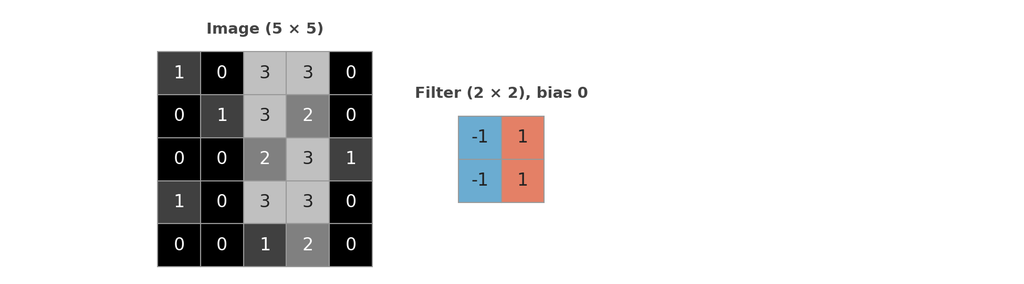

1. Convolve (4 × 4 feature map), apply ReLU, then 2 × 2 max pooling (2 × 2).
2. Flatten the pooled map row by row into $\mathbf{a} = (a_1, a_2, a_3, a_4)$.
3. Dense layer: $z_A = 0.2a_1 + 0.2a_3$ and $z_B = a_2 + a_4$ (biases 0). Compute both scores.
4. Softmax: compute $p_A$ and $p_B$. Use $e^1 \approx 2.72$ and $e^2 \approx 7.39$. Which class is predicted?

## Practice 3: Solution (a) — Convolution, Window by Window

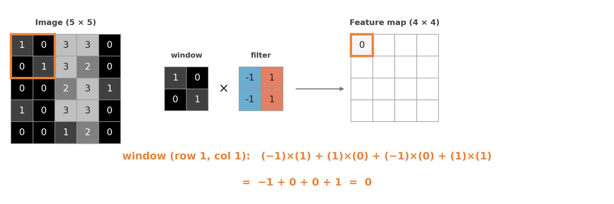

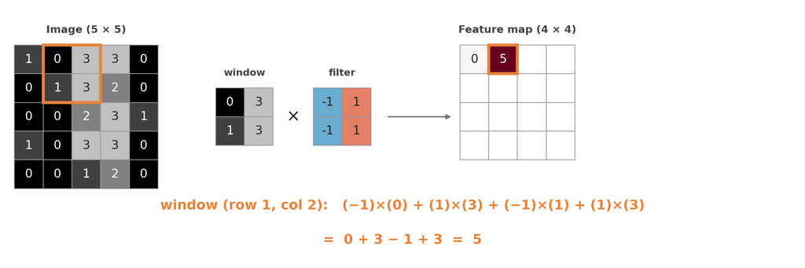

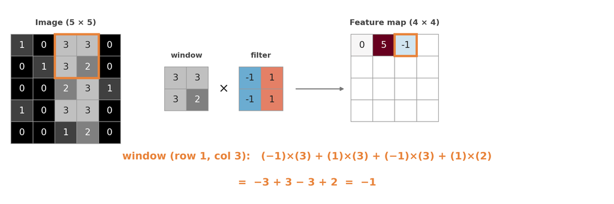

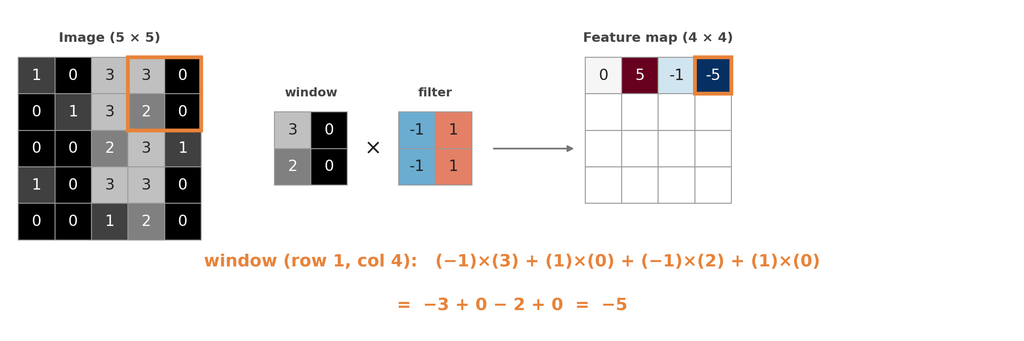

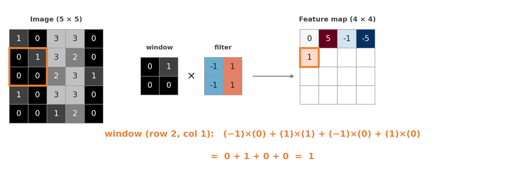

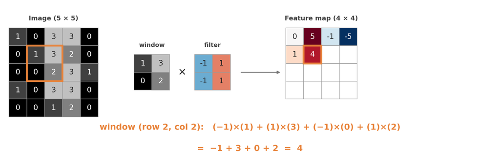

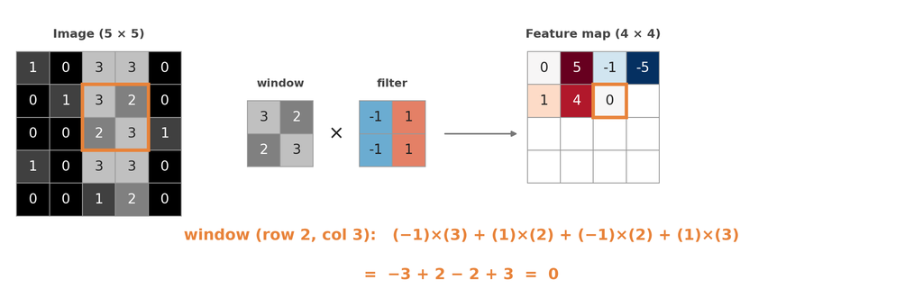

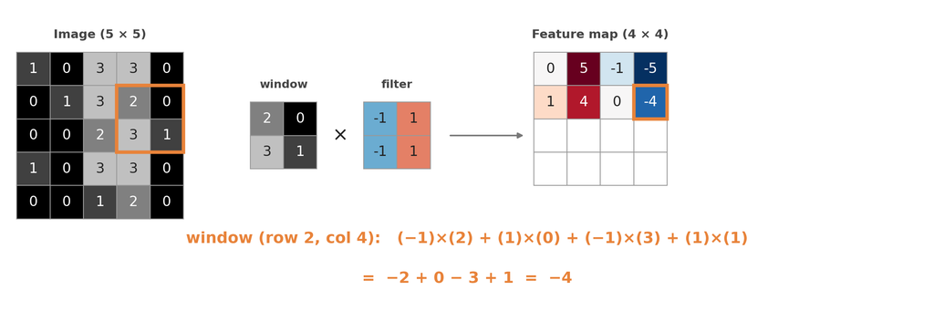

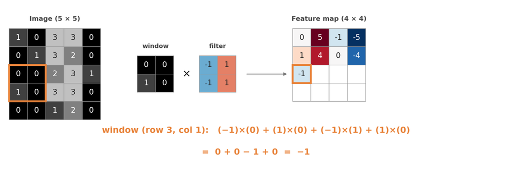

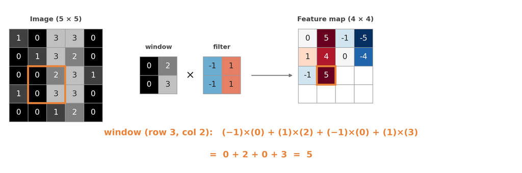

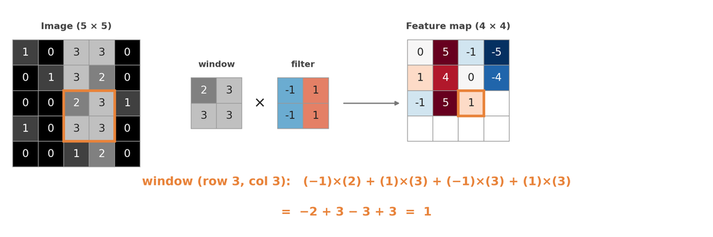

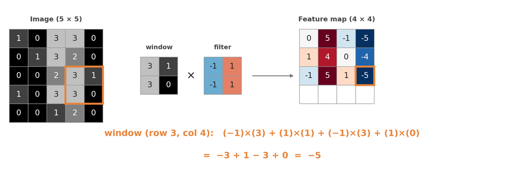

[4 more figures not shown]

## Practice 3: Solution (a) — ReLU, Number by Number

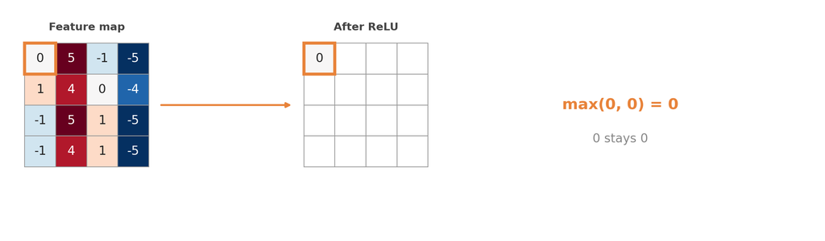

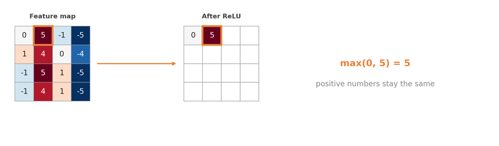

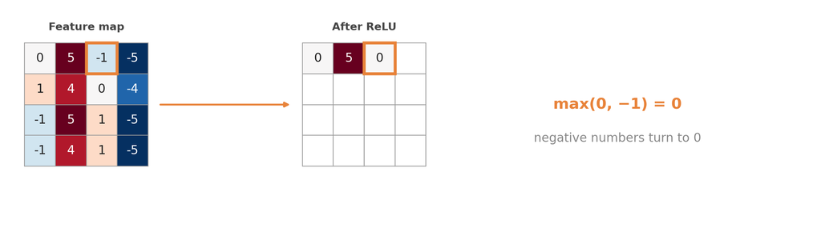

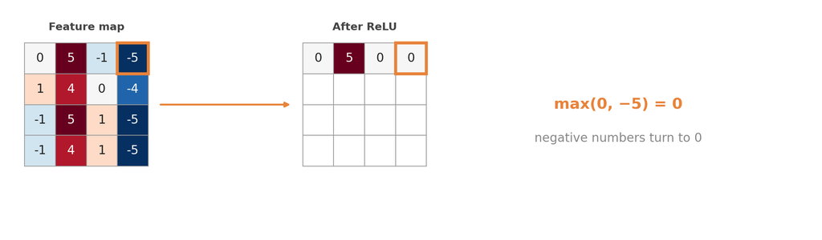

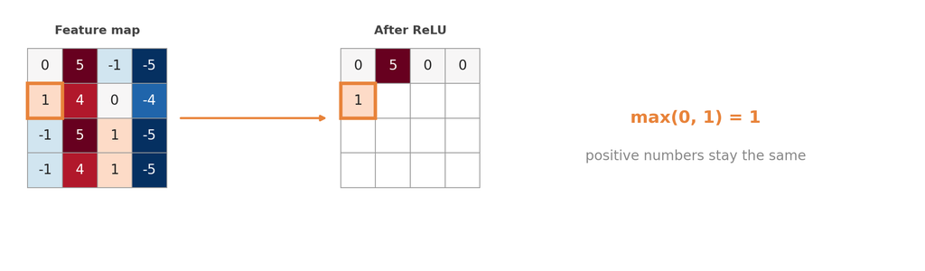

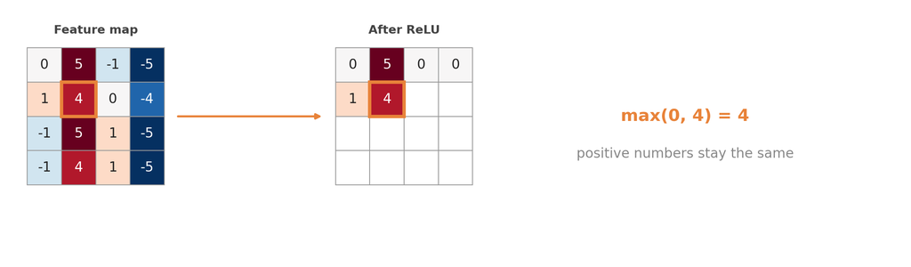

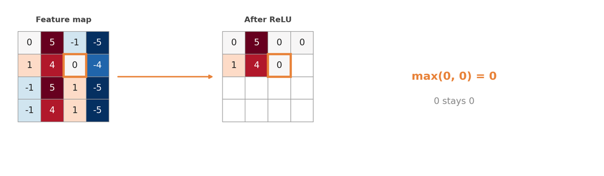

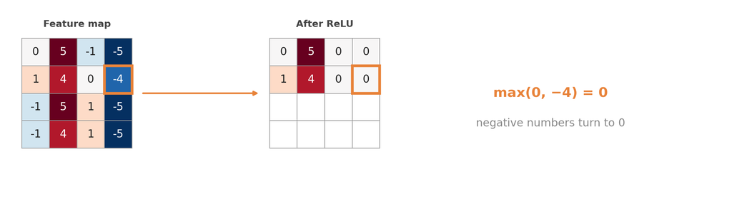

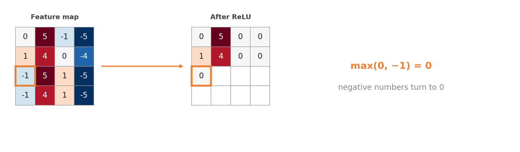

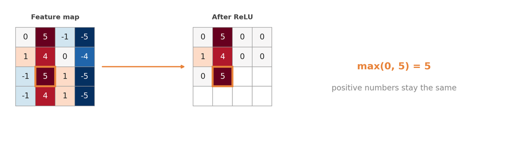

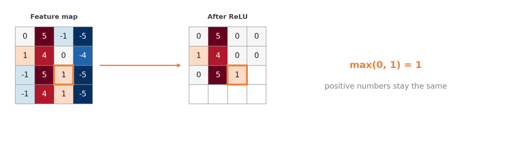

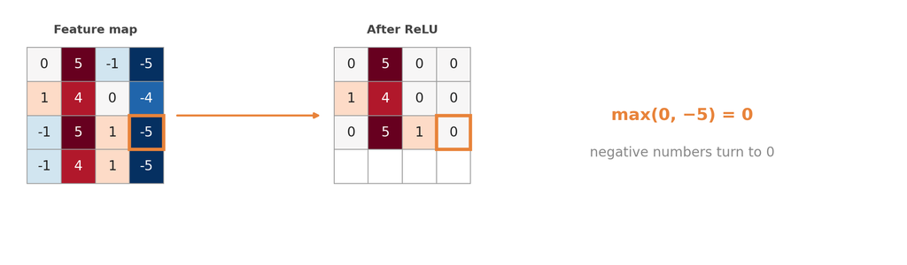

[4 more figures not shown]

## Practice 3: Solution (a, b) — Pooling and Flatten, Block by Block

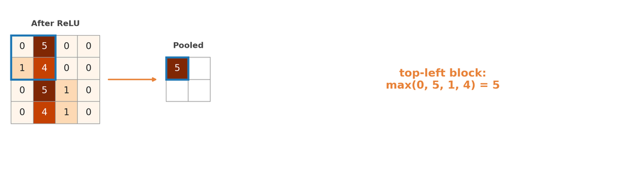

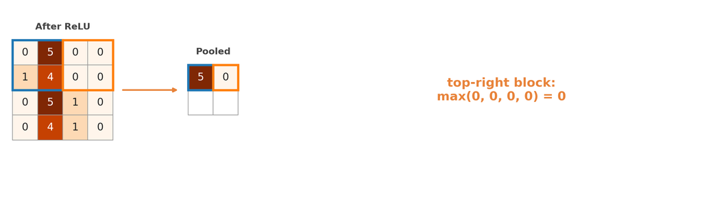

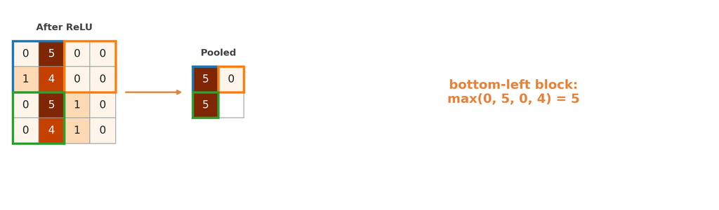

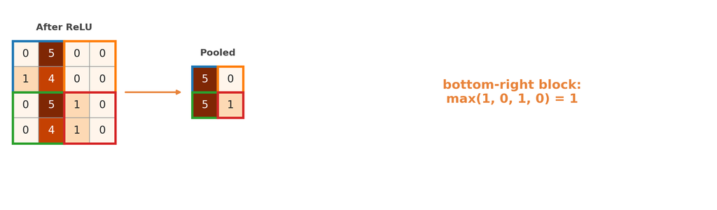

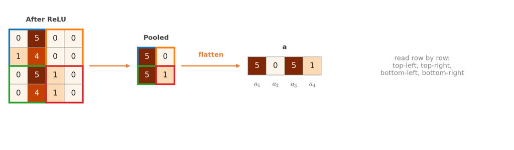

## Practice 3: Solution (c, d) — Dense Layer and Softmax

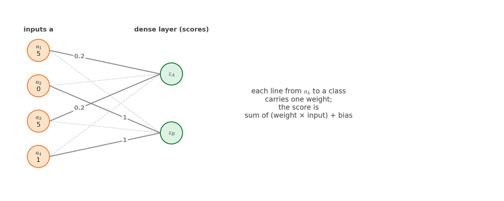

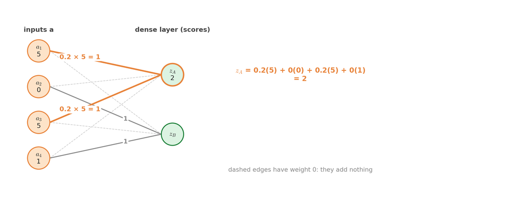

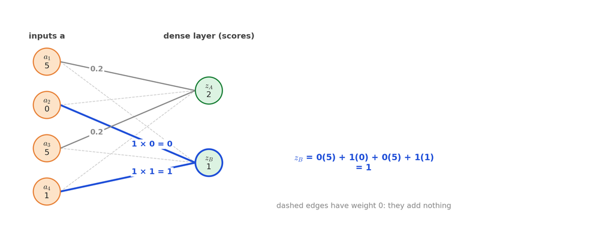

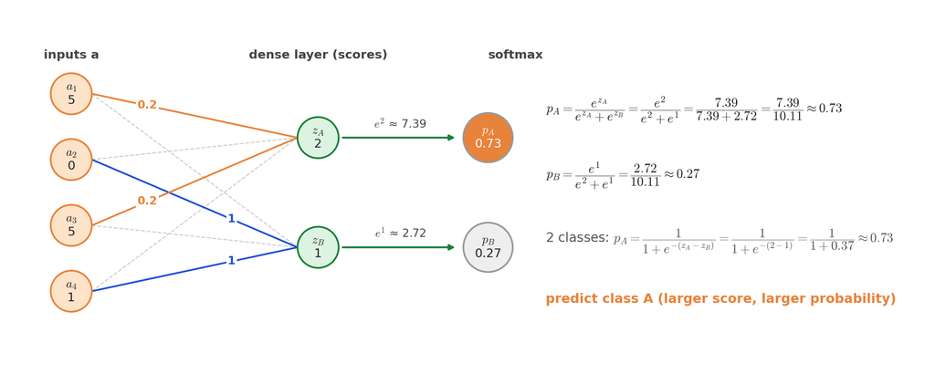

## Practice 4. One Image, Every Step (Color)

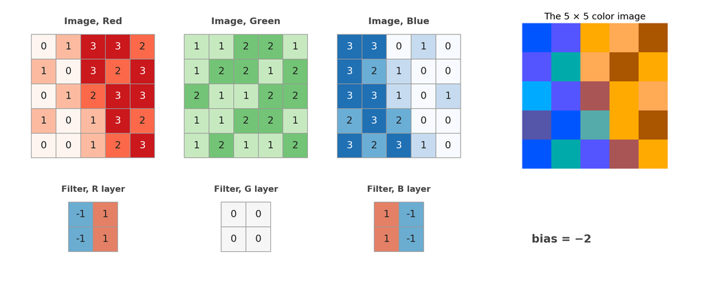

1. The filter is 2 × 2 × 3. Convolve: for each window, compute R part + G part + B part + bias (4 × 4 feature map). Then apply ReLU and 2 × 2 max pooling.
2. Flatten the pooled map row by row into $\mathbf{a} = (a_1, a_2, a_3, a_4)$.
3. Dense layer: $z_A = 0.1a_1 + 0.1a_3$ and $z_B = 0.2a_2 + 0.6a_4$ (biases 0). Compute both scores.
4. Softmax: compute $p_A$ and $p_B$. Use $e^1 \approx 2.72$ and $e^3 \approx 20.09$. Which class is predicted?

## Practice 4: Solution (a) — Convolution, Window by Window

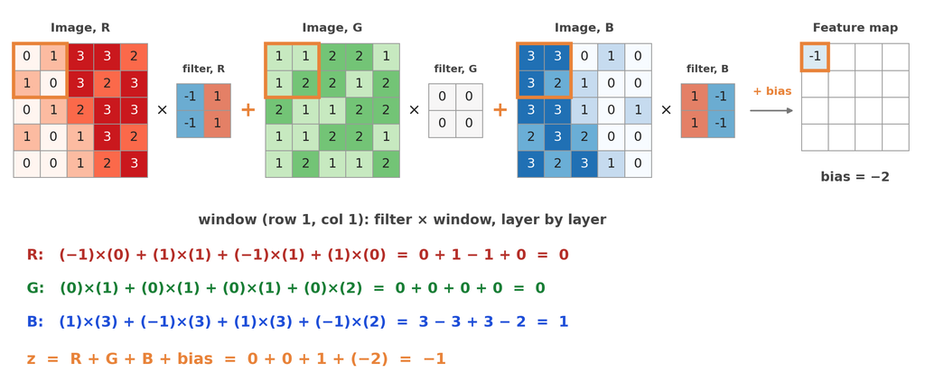

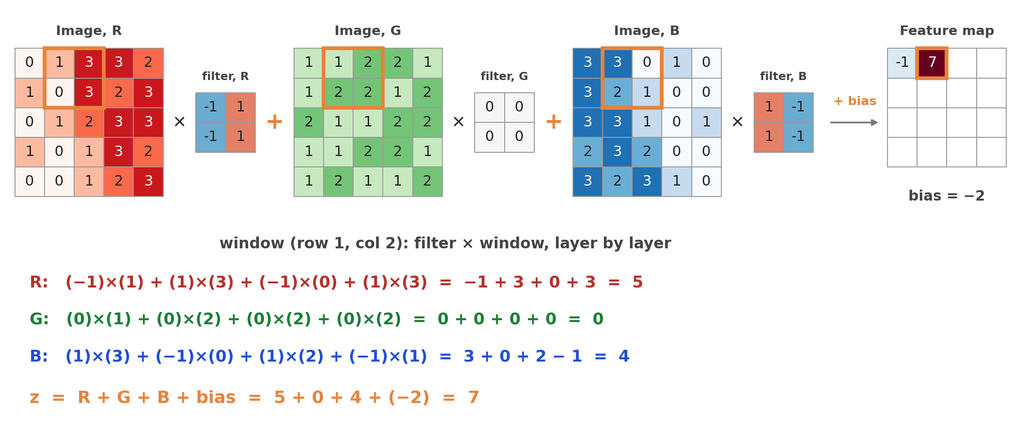

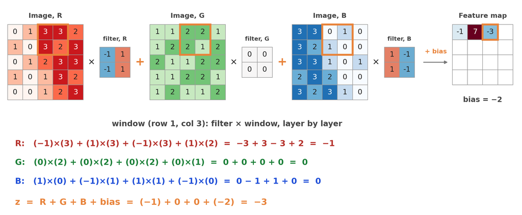

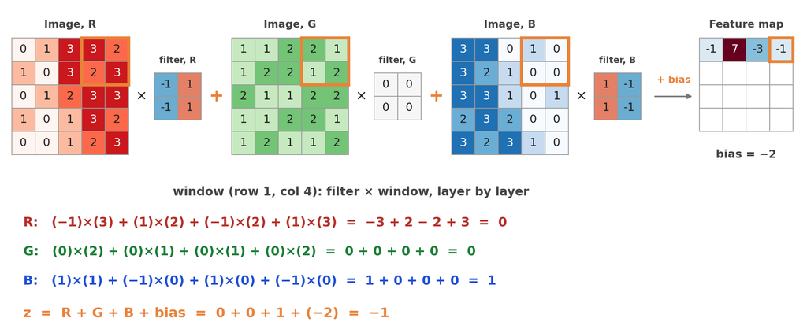

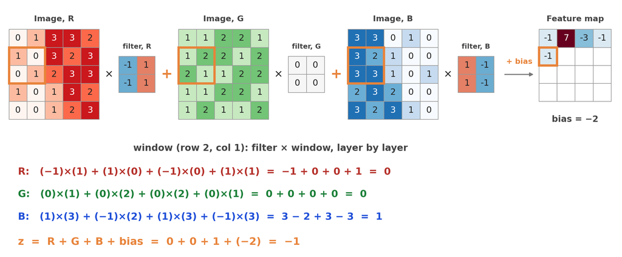

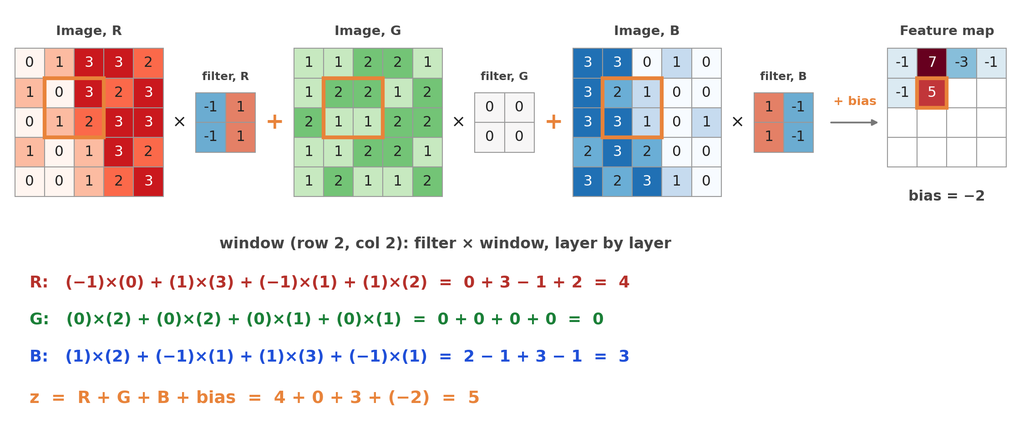

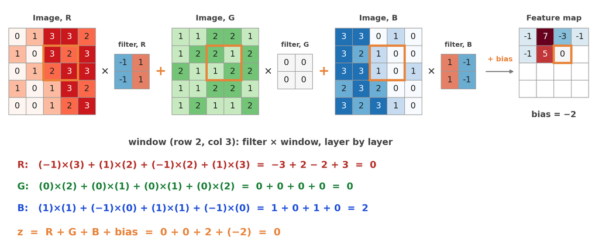

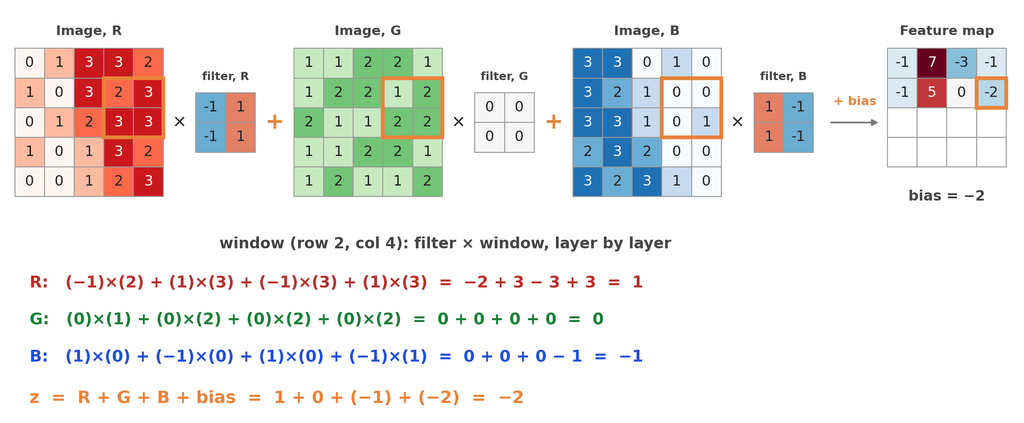

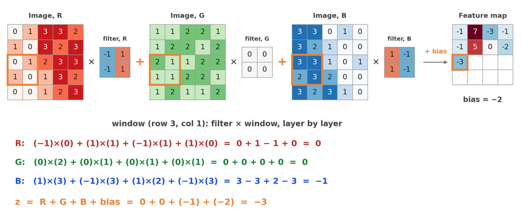

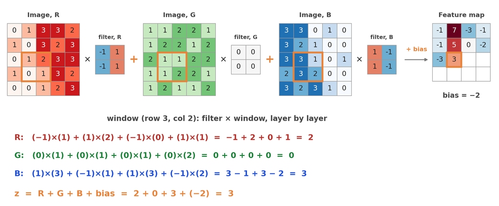

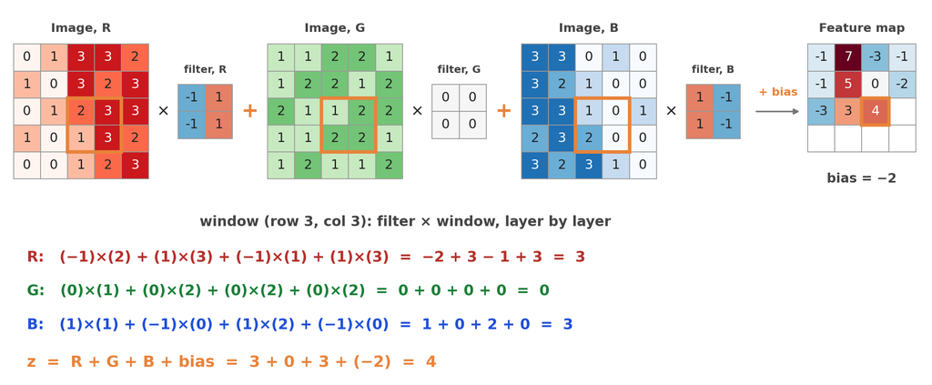

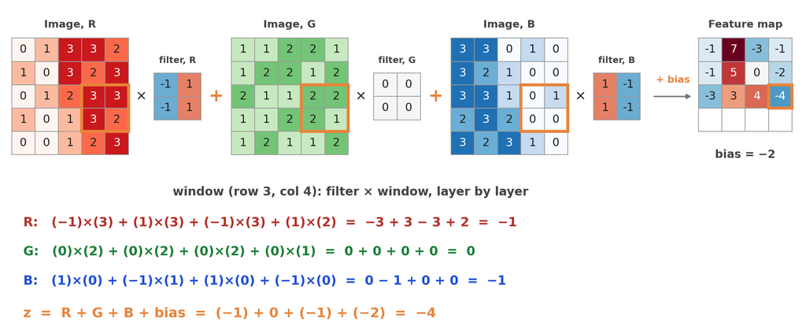

[4 more figures not shown]

## Practice 4: Solution (a) — ReLU, Number by Number

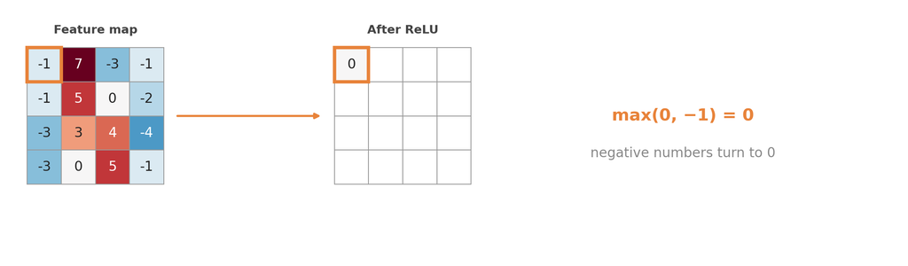

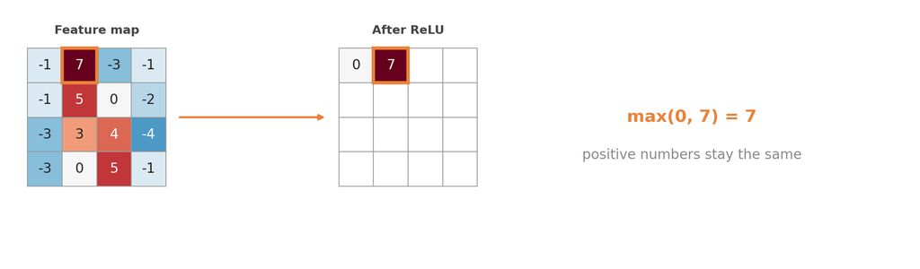

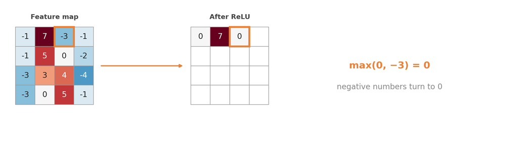

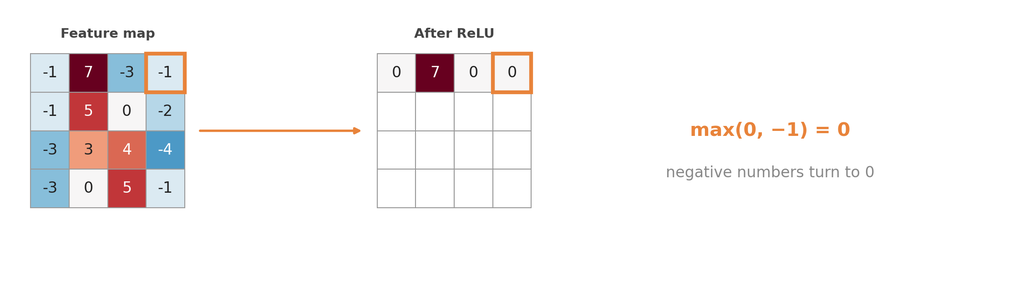

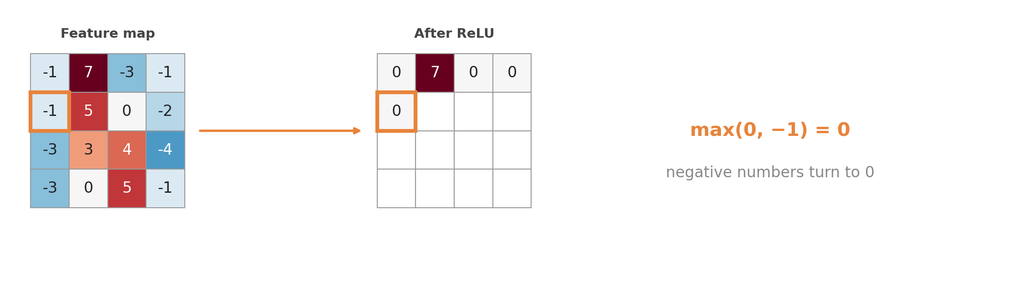

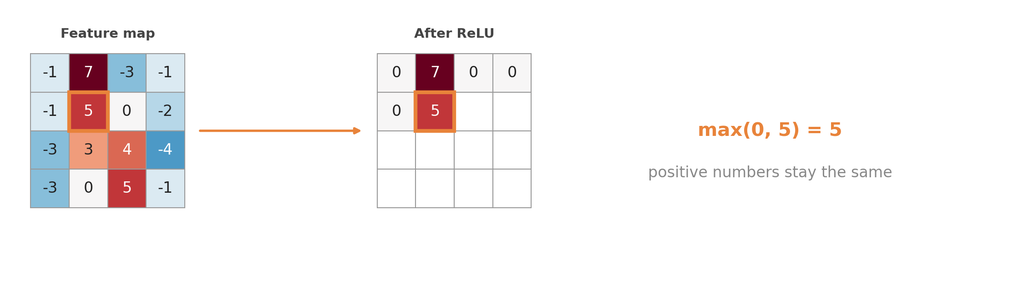

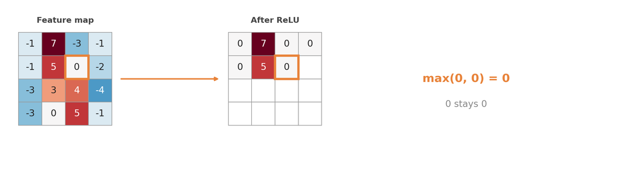

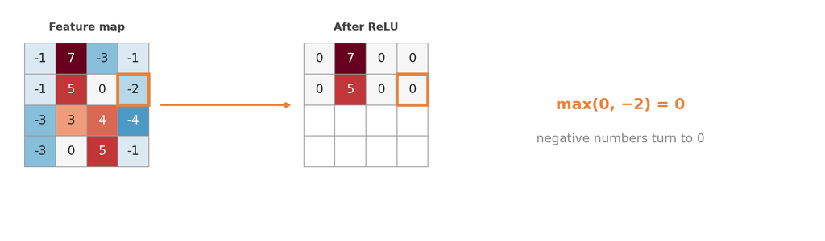

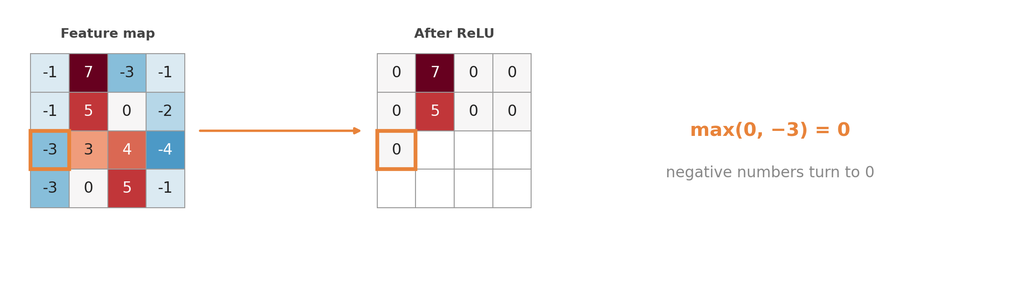

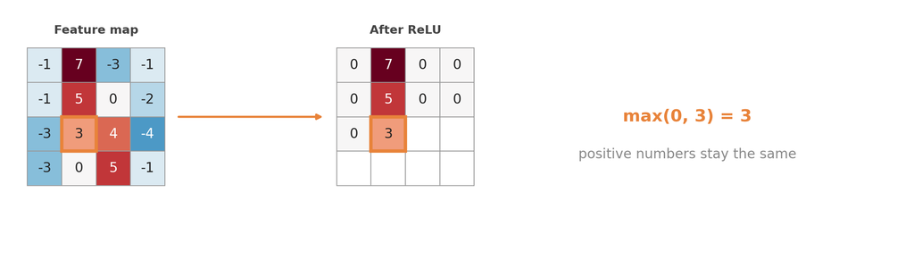

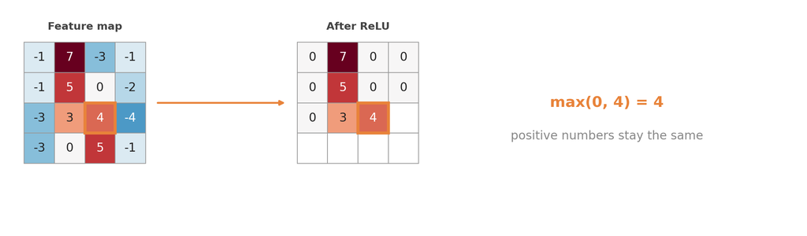

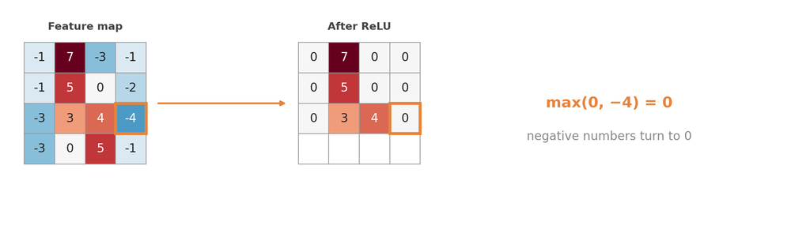

[4 more figures not shown]